# TetlinSwan

Author

Emma Schillerstrom

## Data Clean-Up: Historic Data

Let’s pare down the Alaska Swan Database data set to fit our needs.

First, let’s load our packages, import the data, and put it into a data frame for manipulation. Uncomment the first line to install missing packages.

```r
#install.packages(c("knitr", "corrplot"))
library(knitr)
library(corrplot)
old_df <- read.csv("swanDb.csv")
```

Next, let’s subset the data to only include Tetlin NWR quads, …

```r
map1_quads <- c("A2", "A3", "A4", "B4", "B5", "B6")
map2_quads <- c("B1", "B2", "C1", "C2", "C3", "D1", "D2", "D3", "D4")
old_df <- old_df[which(((old_df$Map == 69) & (old_df$Quad %in% map1_quads)) | ((old_df$Map == 78) & (old_df$Quad %in% map2_quads))),]
```

…remove data from early summer (May, June) nesting surveys and years with little data (pre-1985), …

```r
old_df <- old_df[which((old_df$Month != 5) & (old_df$Month != 6)), ]
old_df <- old_df[which(old_df$Year >= 1985), ]
```

…and remove unnecessary columns, such as those for nesting data (which we are not looking at) or quarter quad numbers (which were never utilized at Tetlin).

```r
old_df <- subset(old_df, select = -c(X, QtrQuad, Nest, Map, Quad))
```

## Data Clean-Up: New Data

Now, let’s format the new data to match the historic data.

Let’s begin again by importing.

```r
new_df <- read.csv("newswans_2022.csv")
```

Next, we’ll remove null-valued rows…

```r
new_df <- new_df[which(new_df$TOTAL != 0),]
```

…and remove extra or unnecessary columns.

```r
new_df <- subset(new_df, select = -c(TOTAL, Pairs, ele, name, ID))
```

We also need to separate out flocks observed with other group types into separate, individual observations (rows). We are going to adjust the latitude value of these “new” observations with an increase of 0.0001.

```r
for(i in 1:nrow(new_df)){
  count = 0
  if((new_df$GroupSize[i] > 0) && (new_df$PAIRSX2[i] > 0)){
    count = count + 1
    addRow <- new_df[i,]
    addRow$GroupSize <- 0
    addRow$Singles <- 0
    addRow$lat <- addRow$lat + count/10000
    new_df <- rbind(new_df, addRow)
    new_df$PAIRSX2[i] <- 0
  }
  if((new_df$GroupSize[i] > 0) && (new_df$Singles[i] > 0)){
    count = count + 1
    addRow <- new_df[i,]
    addRow$GroupSize <- 0
    addRow$PAIRSX2 <- 0
    addRow$lat <- addRow$lat + count/10000
    new_df <- rbind(new_df, addRow)
    new_df$Singles[i] <- 0
  }
}
```

To match the historic data, we’ll add columns for the numbers of adults and young per observation.

```r
new_df$Adults <- new_df$GroupSize + new_df$PAIRSX2 + new_df$Singles
new_df$Young <- new_df$Cygnets
```

We also need to create a new symbology column to identify the group type for each observation. The abbreviations used are as follows: “S” for single no brood, “P” for pair no brood, “SBr” for single with brood, “PBr” for pair with brood, “F” for flock, and “0Br” for lone cygnets.

```r
new_df$Leg_Sym <- NA
for(i in 1:nrow(new_df)){
  if(new_df$Singles[i] > 0){
    if(new_df$Cygnets[i] > 0){
      new_df$Leg_Sym[i] <- "SBr"
    }else{
      new_df$Leg_Sym[i] <- "S"
    }
  }else if(new_df$PAIRSX2[i] > 0){
    if(new_df$Cygnets[i] > 0){
      new_df$Leg_Sym[i] <- "PBr"
    }else{
      new_df$Leg_Sym[i] <- "P"
    }
  }else if(new_df$GroupSize[i] > 0){
    new_df$Leg_Sym[i] <- "F"
  }else{
    new_df$Leg_Sym[i] <- "0Br"
  }
}
```

Now, we can remove columns that were captured by the new symbology column.

```r
new_df <- subset(new_df, select = -c(Singles, PAIRSX2, Cygnets, GroupSize))
```

We will separate out the date column into individual columns for the day, month, and year.

```r
new_df$Month <- as.numeric(substr(new_df$time, 6, 7))
new_df$Day <- as.numeric(substr(new_df$time, 9, 10))
new_df$Year <- as.numeric(substr(new_df$time, 1, 4))
new_df <- subset(new_df, select = -time)
```

The final tweaks require adding a contributor number column and capitalizing the “lat” and “lon” column headers for consistency.

```r
colnames(new_df)[which(colnames(new_df) == "lat")] <- "Lat"
colnames(new_df)[which(colnames(new_df) == "lon")] <- "Lon"
new_df$Contrib <- rep(108,times=nrow(new_df))
```

## Combine Old and New Data

We are ready to combine our data sets.

```r
combined_df <- rbind(old_df, new_df)
```

## Perform Summary Calculations on Full Data Set

(skipped)

```r
# years <- sort(unique(combined_df$Year), decreasing = FALSE)
# total_swans <- c()
# total_adults <- c()
# breeding_adults <- c()
# total_broods <- c()
# total_cygnets <- c()
#
# for (val in years){
#   total_swans <- append(total_swans, sum(combined_df$Adults[which(combined_df$Year == val)], combined_df$Young[which(combined_df$Year == val)]))
#   total_adults <- append(total_adults, sum(combined_df$Adults[which(combined_df$Year == val)]))
#   breeding_adults <- append(breeding_adults, sum(combined_df$Adults[which(combined_df$Year == val & (combined_df$Leg_Sym == "PBr" | combined_df$Leg_Sym == "SBr"))]))
#   total_broods <- append(total_broods, length(which(combined_df$Year == val & combined_df$Young > 1)))
#   total_cygnets <- append(total_cygnets, sum(combined_df$Young[which(combined_df$Year == val)]))
# }
#
# proportion_breeding <- breeding_adults/total_adults
# avg_brood_size <- total_cygnets/total_broods
#
# annual_growth_rate <- c(0)
# for (i in 2:length(total_swans)){
#   rate <- round((total_swans[i]/total_swans[i-1])^(1/(years[i]-years[i-1]))-1, digits=4)
#   annual_growth_rate <- append(annual_growth_rate, rate)
# }
#
# summary_df <- data.frame(years, total_swans, annual_growth_rate, breeding_adults, proportion_breeding, total_broods, total_cygnets, avg_brood_size)
# kable(summary_df)
```

## Import Data Subsets Restricted to New Boundaries

```r
PVC95_df <- read.csv("vals_within_PVC95.csv")
PVC98_df <- read.csv("vals_within_PVC98.csv")
buffer_df <- read.csv("vals_within_buffer.csv")
MBMpoly_df <- read.csv("vals_within_MBMpolygon.csv")
bounded_data <- list(PVC95_df, PVC98_df, buffer_df, MBMpoly_df)
titles <- c("95% PVC", "98% PVC", "800m Flight Path Buffer", "MBM Waterfowl Polygon")
```

## Retrieve New Summary Calculations

```r
summarize <- function(df){
  years <- sort(unique(df$Year), decreasing = FALSE)
  years <- years[which(years >= 1985)]

  total_swans <- c()
  total_adults <- c()
  breeding_adults <- c()
  total_broods <- c()
  total_cygnets <- c()

  for (val in years){
    total_swans <- append(total_swans, sum(df$Adults[which(df$Year == val)], df$Young[which(df$Year == val)]))
    total_adults <- append(total_adults, sum(df$Adults[which(df$Year == val)]))
    breeding_adults <- append(breeding_adults, sum(df$Adults[which(df$Year == val & (df$Leg_Sym == "PBr" | df$Leg_Sym == "SBr"))]))
    total_broods <- append(total_broods, length(which(df$Year == val & df$Young > 1)))
    total_cygnets <- append(total_cygnets, sum(df$Young[which(df$Year == val)]))
  }

  proportion_breeding <- breeding_adults/total_adults
  avg_brood_size <- total_cygnets/total_broods

  annual_growth_rate <- c(0)
  for (i in 2:length(total_swans)){
    rate <- round((total_swans[i]/total_swans[i-1])^(1/(years[i]-years[i-1]))-1, digits=4)
    annual_growth_rate <- append(annual_growth_rate, rate)
  }

  summary_df <- data.frame(years, total_swans, annual_growth_rate, breeding_adults, proportion_breeding, total_broods, total_cygnets, avg_brood_size)
  return(summary_df)
}
```

## Compare Tables

```r
for (i in 1:length(bounded_data)){
  print(kable(summarize(bounded_data[[i]])))
  cat("\n")
}
```

```
| years| total_swans| annual_growth_rate| breeding_adults| proportion_breeding| total_broods| total_cygnets| avg_brood_size|
|-----:|-----------:|------------------:|---------------:|-------------------:|------------:|-------------:|--------------:|
|  1985|         102|             0.0000|              18|           0.2571429|            9|            32|       3.555556|
|  1986|          94|            -0.0784|              14|           0.2000000|            7|            24|       3.428571|
|  1987|         113|             0.2021|              10|           0.1041667|            5|            17|       3.400000|
|  1988|         145|             0.2832|              26|           0.2680412|           12|            48|       4.000000|
|  1989|         206|             0.4207|              36|           0.2571429|           17|            66|       3.882353|
|  1990|         302|             0.4660|              64|           0.3786982|           31|           133|       4.290323|
|  1991|         329|             0.0894|              48|           0.1975309|           20|            86|       4.300000|
|  1992|         330|             0.0030|              47|           0.1828794|           21|            73|       3.476190|
|  1993|         292|            -0.1152|              46|           0.2254902|           22|            88|       4.000000|
|  1994|         435|             0.4897|              84|           0.3054545|           38|           160|       4.210526|
|  1995|         607|             0.3954|             104|           0.2512077|           48|           193|       4.020833|
|  2000|         997|             0.1043|             151|           0.2046070|           68|           259|       3.808823|
|  2005|        1399|             0.0701|             219|           0.2230143|          105|           417|       3.971429|
|  2010|        1482|             0.0116|             179|           0.1528608|           81|           311|       3.839506|
|  2015|        1862|             0.0467|             190|           0.1191223|           76|           267|       3.513158|
|  2022|        1066|            -0.0766|             139|           0.1570621|           46|           181|       3.934783|



| years| total_swans| annual_growth_rate| breeding_adults| proportion_breeding| total_broods| total_cygnets| avg_brood_size|
|-----:|-----------:|------------------:|---------------:|-------------------:|------------:|-------------:|--------------:|
|  1985|         102|             0.0000|              18|           0.2571429|            9|            32|       3.555556|
|  1986|          94|            -0.0784|              14|           0.2000000|            7|            24|       3.428571|
|  1987|         115|             0.2234|              10|           0.1020408|            5|            17|       3.400000|
|  1988|         146|             0.2696|              26|           0.2653061|           12|            48|       4.000000|
|  1989|         208|             0.4247|              36|           0.2535211|           17|            66|       3.882353|
|  1990|         302|             0.4519|              64|           0.3786982|           31|           133|       4.290323|
|  1991|         331|             0.0960|              48|           0.1959184|           20|            86|       4.300000|
|  1992|         331|             0.0000|              47|           0.1821705|           21|            73|       3.476190|
|  1993|         293|            -0.1148|              46|           0.2243902|           22|            88|       4.000000|
|  1994|         435|             0.4846|              84|           0.3054545|           38|           160|       4.210526|
|  1995|         609|             0.4000|             104|           0.2500000|           48|           193|       4.020833|
|  2000|        1013|             0.1071|             155|           0.2066667|           69|           263|       3.811594|
|  2005|        1446|             0.0738|             223|           0.2186275|          107|           426|       3.981308|
|  2010|        1514|             0.0092|             187|           0.1571429|           84|           324|       3.857143|
|  2015|        1912|             0.0478|             192|           0.1167883|           76|           268|       3.526316|
|  2022|        1096|            -0.0764|             141|           0.1551155|           47|           187|       3.978723|

```

[output cut: 26 more lines]

```
|  1986|          73|            -0.0135|               8|           0.1379310|            4|            15|       3.750000|
|  1987|         100|             0.3699|              10|           0.1204819|            5|            17|       3.400000|
|  1988|         114|             0.1400|              18|           0.2195122|            8|            32|       4.000000|
|  1989|         169|             0.4825|              28|           0.2393162|           13|            52|       4.000000|
|  1990|         254|             0.5030|              54|           0.3724138|           26|           109|       4.192308|
|  1991|         290|             0.1417|              42|           0.1891892|           17|            68|       4.000000|
|  1992|         282|            -0.0276|              41|           0.1880734|           19|            64|       3.368421|
|  1993|         236|            -0.1631|              32|           0.1839080|           15|            62|       4.133333|
|  1994|         340|             0.4407|              64|           0.2857143|           29|           116|       4.000000|
|  1995|         507|             0.4912|              80|           0.2234637|           37|           149|       4.027027|
|  2000|         867|             0.1133|             127|           0.1938931|           57|           212|       3.719298|
|  2005|        1216|             0.0700|             181|           0.2061503|           86|           338|       3.930233|
|  2010|        1319|             0.0164|             169|           0.1666667|           78|           305|       3.910256|
|  2015|        1716|             0.0540|             158|           0.1058981|           65|           224|       3.446154|
|  2022|         959|            -0.0798|             129|           0.1630847|           42|           168|       4.000000|
```

## Compare Plots

#### Total Swans

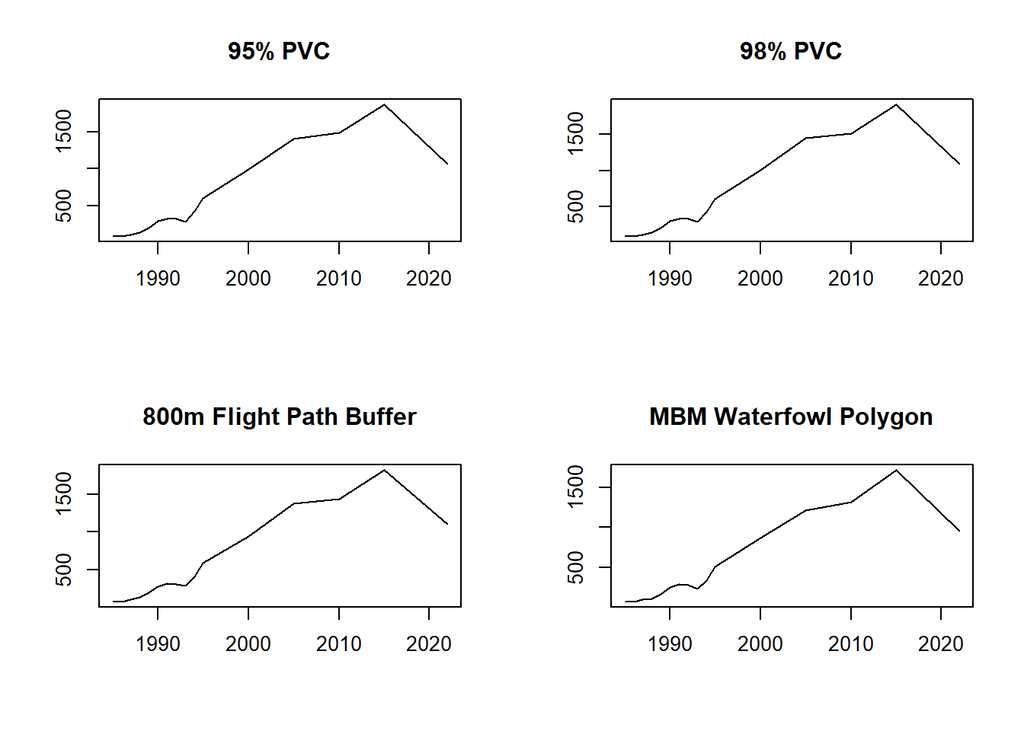

```r
par(mfrow = c(2, 2))
for (i in 1:length(bounded_data)){
  plot(summarize(bounded_data[[i]])$years, summarize(bounded_data[[i]])$total_swans, type="l", main = titles[i], xlab="", ylab="")
}
```

#### Breeding Adults

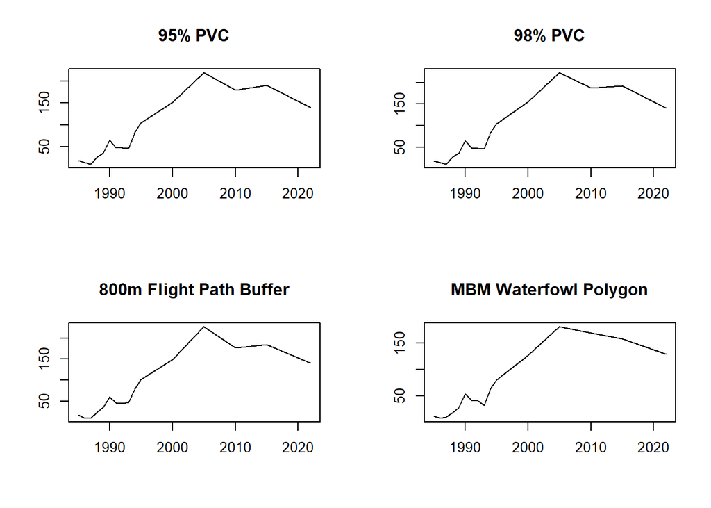

```r
par(mfrow = c(2, 2))
for (i in 1:length(bounded_data)){
  plot(summarize(bounded_data[[i]])$years, summarize(bounded_data[[i]])$breeding_adults, type="l", main = titles[i], xlab="", ylab="")
}
```

#### Total Cygnets

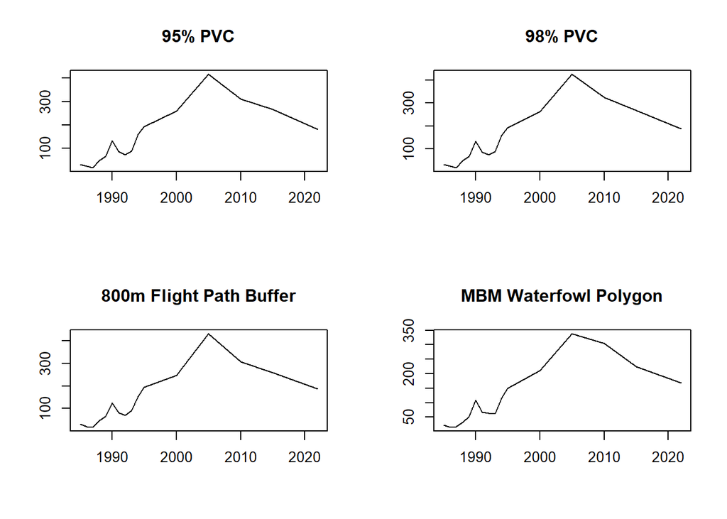

```r
par(mfrow = c(2, 2))
for (i in 1:length(bounded_data)){
  plot(summarize(bounded_data[[i]])$years, summarize(bounded_data[[i]])$total_cygnets, type="l", main = titles[i], xlab="", ylab="")
}
```

#### Annual Growth Rate

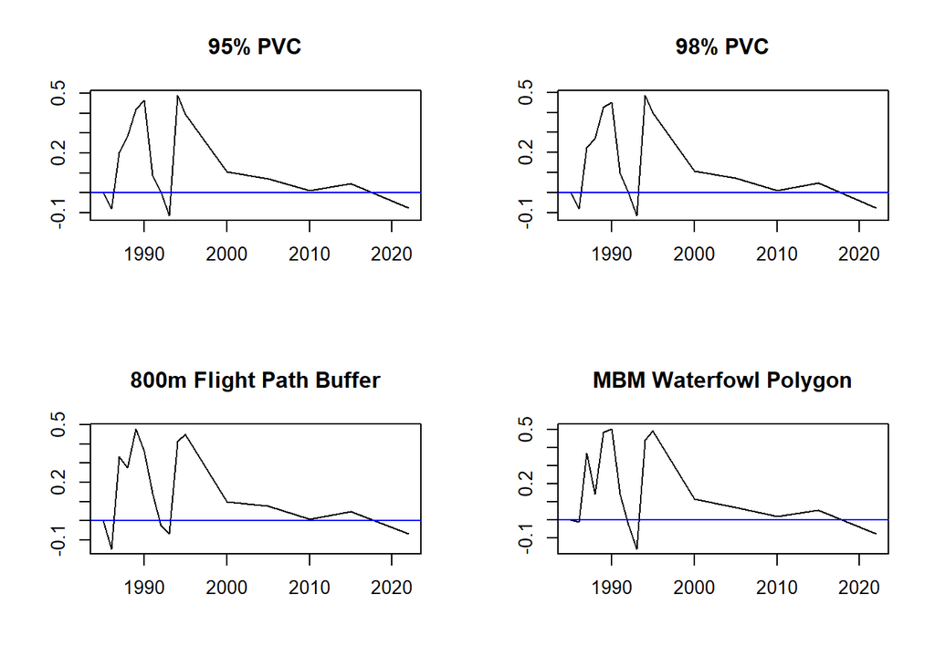

```r
par(mfrow = c(2, 2))
for (i in 1:length(bounded_data)){
  plot(summarize(bounded_data[[i]])$years, summarize(bounded_data[[i]])$annual_growth_rate, type="l", main = titles[i], xlab="", ylab="")
  abline(h=0, col="blue")
}
```

#### Proportion Breeding

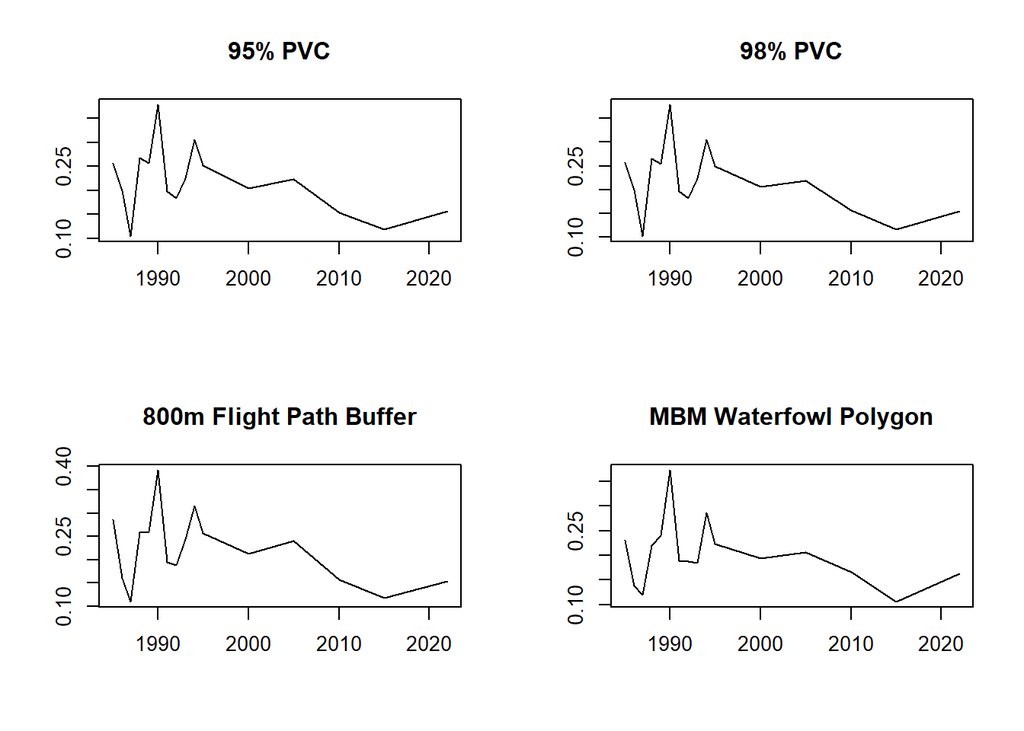

```r
par(mfrow = c(2, 2))
for (i in 1:length(bounded_data)){
  plot(summarize(bounded_data[[i]])$years, summarize(bounded_data[[i]])$proportion_breeding, type="l", main = titles[i], xlab="", ylab="")
}
```

#### Average Brood Size

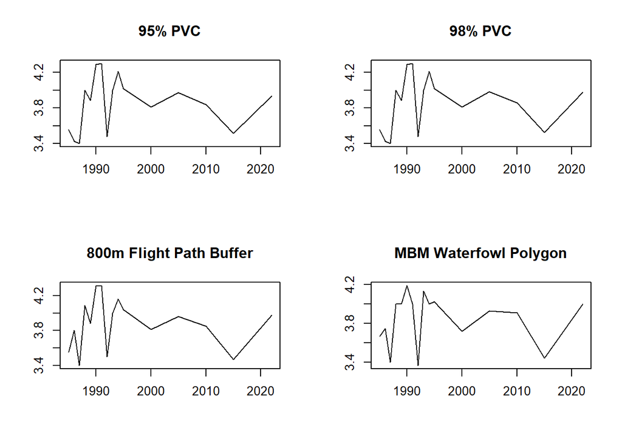

```r
par(mfrow = c(2, 2))
for (i in 1:length(bounded_data)){
  plot(summarize(bounded_data[[i]])$years, summarize(bounded_data[[i]])$avg_brood_size, type="l", main = titles[i], xlab="", ylab="")
}
```

## Compare Correlation Matrices

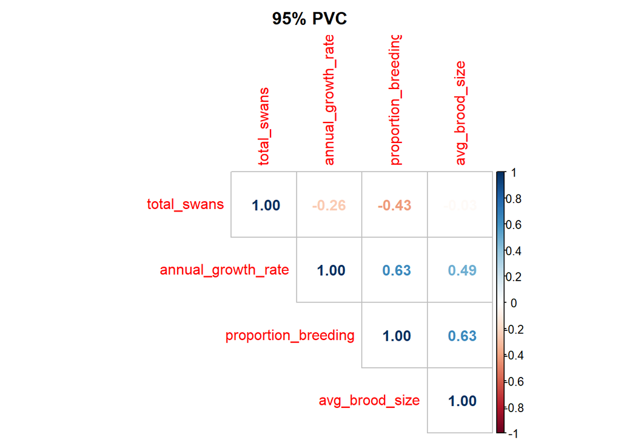

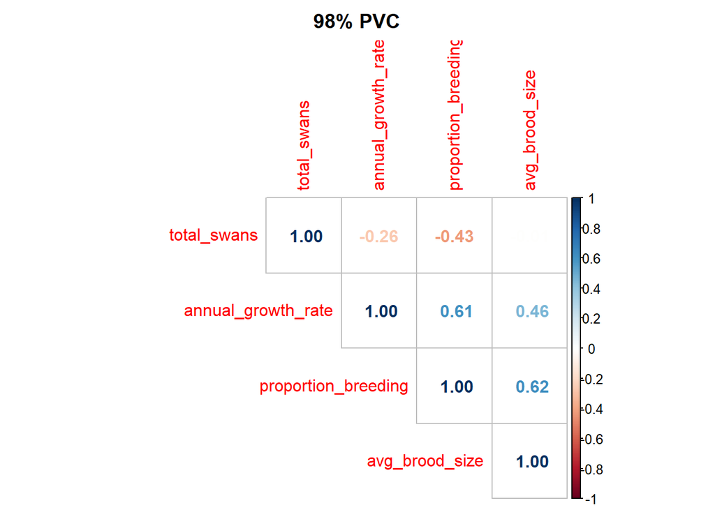

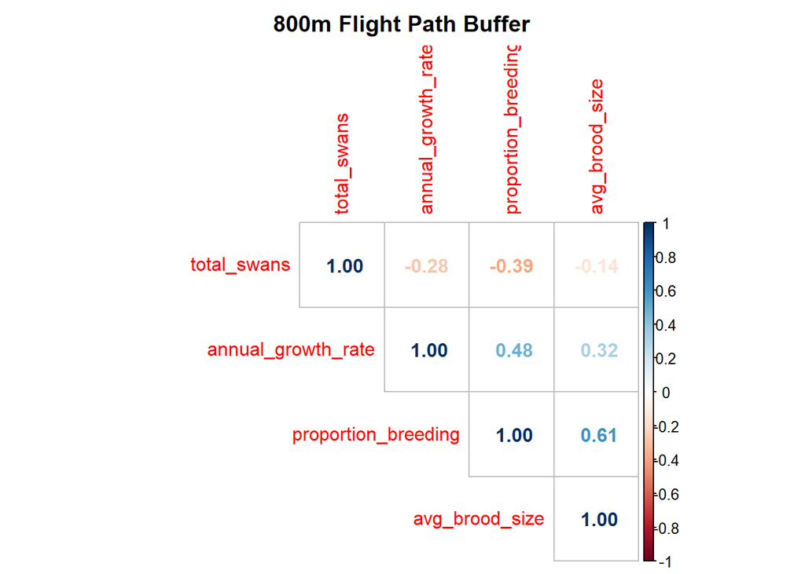

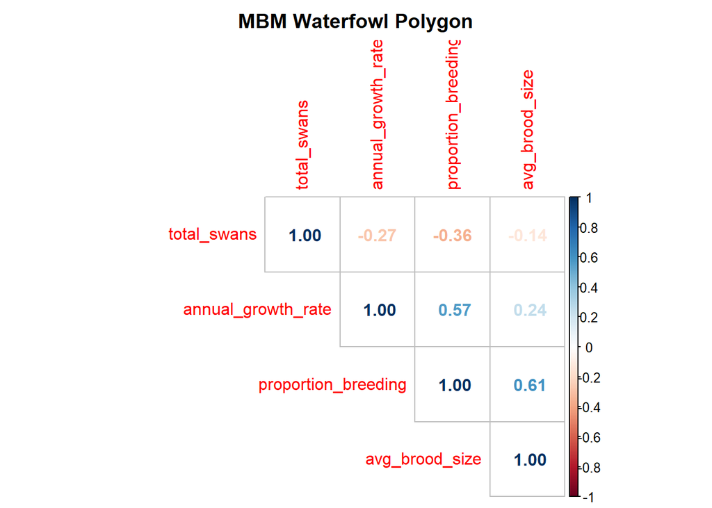

```r
#corrplot(cor(updated_summary_df))
for (i in 1:length(bounded_data)){
  corrplot(cor(subset(summarize(bounded_data[[i]]), select = -c(breeding_adults, total_broods, years, total_cygnets))), type = "upper", method = "number", title = titles[i], mar=c(0,0,2,0))
  #corrplot(cor(summarize(bounded_data[[i]])), type = "upper", method = "number", title = titles[i], mar=c(0,0,2,0))
}
```

## Example Report

Let’s get some variables prepared.

```r
df <- summarize(buffer_df)
index <- which(df$years == max(df$years))
current_year <- df$years[index]
start_month <- min(unique(combined_df$Month[which(combined_df$Year == current_year)]))
start_day <- min(unique(combined_df$Day[which(combined_df$Year == current_year & combined_df$Month == start_month)]))
end_month <- max(unique(combined_df$Month[which(combined_df$Year == current_year)]))
end_day <- max(unique(combined_df$Day[which(combined_df$Year == current_year & combined_df$Month == end_month)]))
if(df$total_swans[index] > df$total_swans[index-1]){
  total_change <- "increase"
}else{
  total_change <- "decrease"
}
if(df$total_swans[index] > df$total_swans[index-1]){
  breeding_change <- "increased"
}else{
  breeding_change <- "decreased"
}
```

#### Here is what that report can look like:

In 2022, the trumpeter swan census survey was flown from 8/16 to 8/18. 1103 total swans were counted during the survey, which is a 39.3% decrease since the previous survey flown in 2015. The population growth rate since the last survey was about -6.88% annually.